# 3152022_analysis

Tanvi Ingle

3/16/2022

Libraries

Common Functions & Base directory

### **Objective**

Here I will analyze the results from the promoter and terminator optimization run on 3-15-2022. These results are form the new optimization algorithm that differs from previous algorithms in several distinct ways:

1. In addition to the three terminators (pA, pB, pD), the four terminators (tJ, tF, tG, tH) are also being optimized.
2. Terminator optimization is additive (+/- step of 0.05)
3. Promoter optimization still multiplicative ( [randomly select step size + 1] * multiply existing exponent value).
- Ex Step ‘back’: pA = e^3; randomly select -0.4 –> 0.6 scale; so pA = e^(3*0.6)
- Ex Step ’forward: pA = e^3; randomly select +0.4 –> 1.4 scale; so pA = e^(3*1.4)

### **Change in Error over Generations**

These results look the best out of all the previous optimizations!!

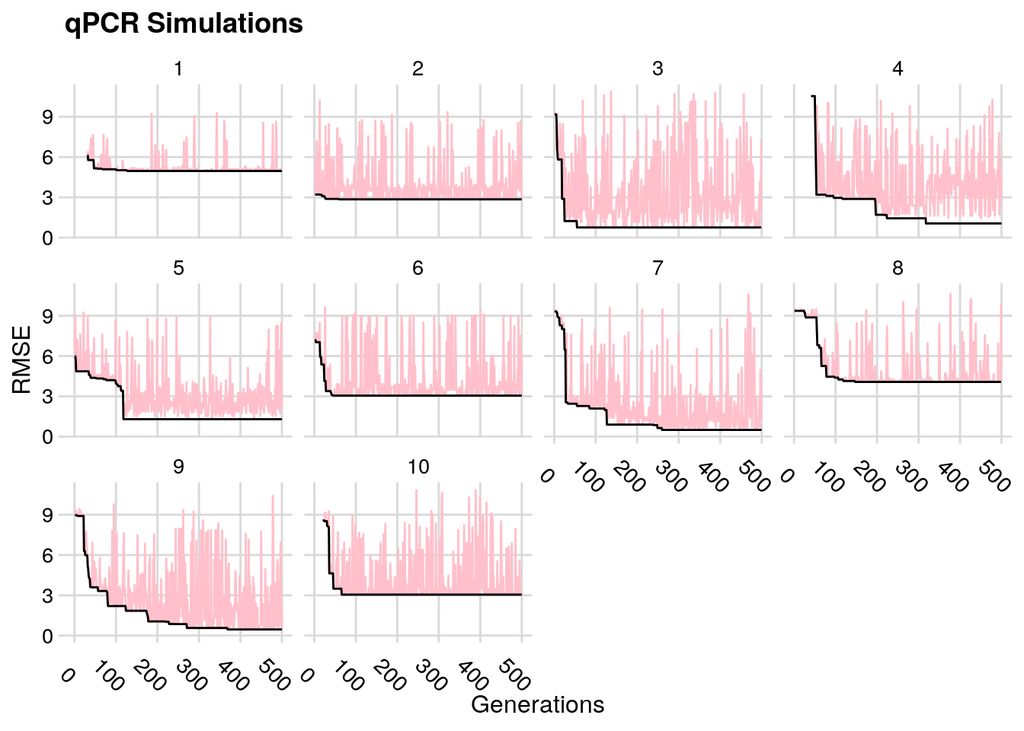

### **Final Minimum Errors**

Here, I look at the best minimal errors to see if the promoter and terminator values are converging. Note, since there are only 5 good simulations (min error < 2) at the moment it is hard to find any strong pattern. This is mostly exploratory.

**Terminator values**

From the Logel 2020 paper, the experimental fold change analysis showed terminator strengths as follows: tJ = tG = 0.3ish and tF = 0.2ish and tH = 0.7ish.

tJ = tG was vaguely observed in sims 3 and 7 and NOT observed in sims 4 and 5. Sims 4 and 5 had higher errors so this is fine. More (concerining?) is that it was not observed in sim 9 which has the lowest error. In sim 9, tG had a very high value….not sure why.

**Promoter values**

**Outstanding Questions**

1. Terminator values are not converging convincingly enough – plan to run for more simulations (total 30? it only took 3ish hours to run 10 sims) and generations (1000? although only incremental gains were found after 400 generations). Also use smaller step size (0.05 –> 0.01).
2. Promoter values converging but in a pattern inconsistent with experimental data (Logel 2020). I don’t have a good biological reason for this – is there some regulatory dynamic I am not modeling?

| sim | gen | pA | pB | pD | tJ | tF | tG | tH | error | min_error |
| --- | --- | --- | --- | --- | --- | --- | --- | --- | --- | --- |
| 9 | 369 | 12.53502 | 14.484942 | 16.164972 | 0.3900596 | 0.5108327 | 0.9630206 | 0.2435810 | 0.45782 | 0.45782 |
| 7 | 260 | 13.04585 | 15.222113 | 18.342678 | 0.3129013 | 0.6671101 | 0.4105418 | 0.7791773 | 0.50039 | 0.50039 |
| 3 | 55 | 11.19431 | 13.569033 | 14.060355 | 0.4954233 | 0.5174992 | 0.6613975 | 0.1200260 | 0.76079 | 0.76079 |
| 4 | 318 | 11.42551 | 12.328219 | 13.710533 | 0.1243843 | 0.3560872 | 0.7759247 | 0.7073769 | 1.05865 | 1.05865 |
| 5 | 118 | 13.47064 | 15.540423 | 20.974678 | 0.4919579 | 0.0812258 | 0.7132073 | 0.8438884 | 1.29833 | 1.29833 |
| 2 | 60 | 12.77141 | 5.481607 | 16.088380 | 0.5158708 | 0.7471515 | 0.1065759 | 0.4309031 | 2.85428 | 2.85428 |
| 10 | 66 | 12.61861 | 8.497055 | 16.156981 | 0.1263237 | 0.9527765 | 0.3674411 | 0.1662893 | 3.05069 | 3.05069 |
| 6 | 46 | 11.96402 | 5.605311 | 14.568546 | 0.0611099 | 0.8705051 | 0.9019197 | 0.9394725 | 3.05402 | 3.05402 |
| 8 | 147 | 11.74423 | 7.741990 | 14.896831 | 0.9292869 | 0.5931867 | 0.6878307 | 0.5648678 | 4.07289 | 4.07289 |
| 1 | 127 | 13.58301 | 20.416612 | 7.969476 | 0.7311852 | 0.9608782 | 0.9078087 | 0.2606619 | 4.96141 | 4.96141 |

### **Final Transcript Abundances**

Sim 9 is the best in matching qPCR data from Logel 2020.

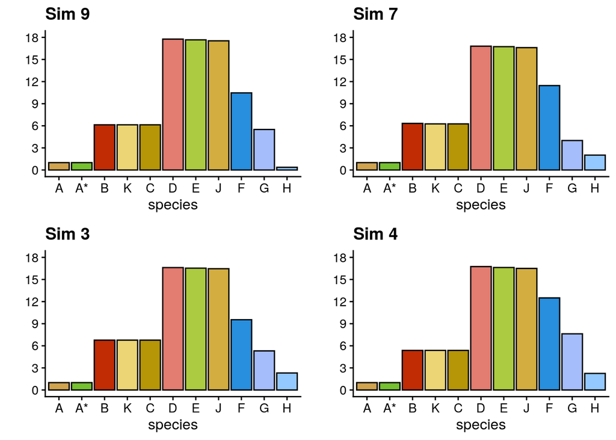

### **Evolution of transcript abundances over generations for the best sims**

Doesn’t always improve over time - which is ok since sometimes the algorithm cannot find better parameter values.

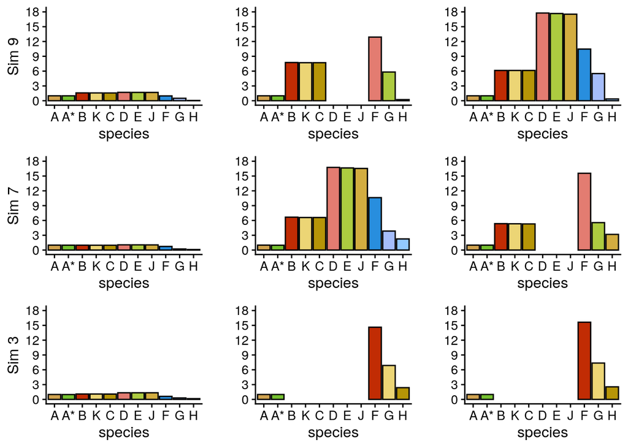

### **How do parameter values change over time?**

I think the promoter values are exploring the parameter space just fine. For terminators, I want to repeat this analysis but with a smaller step size of 0.01. It needs some more fine tuning.

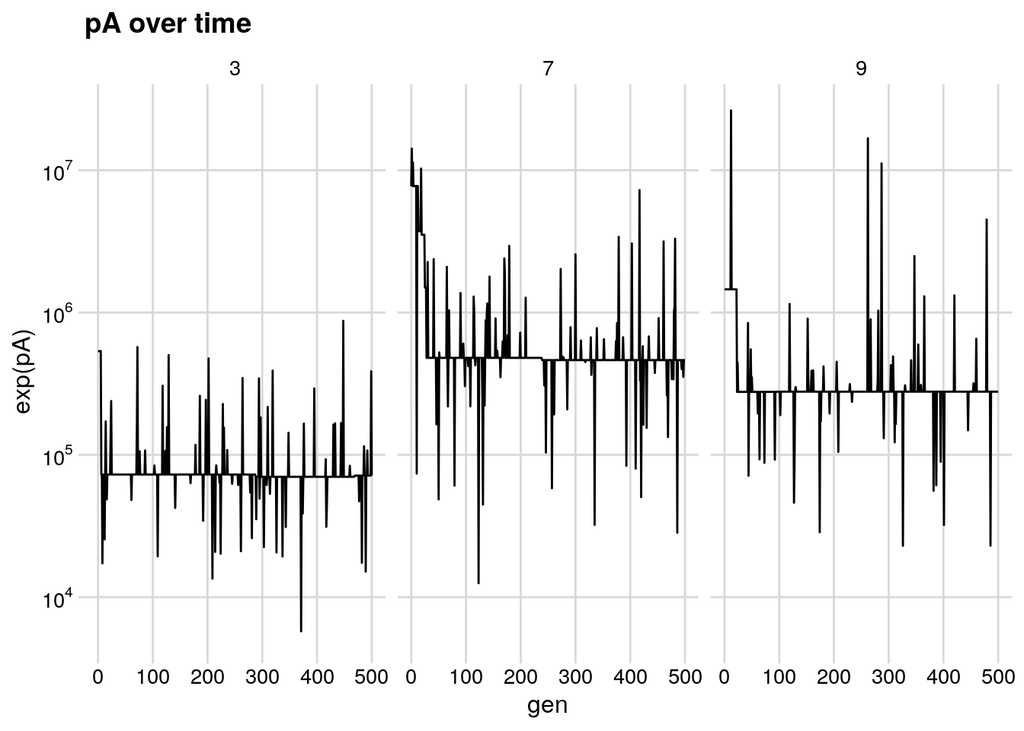

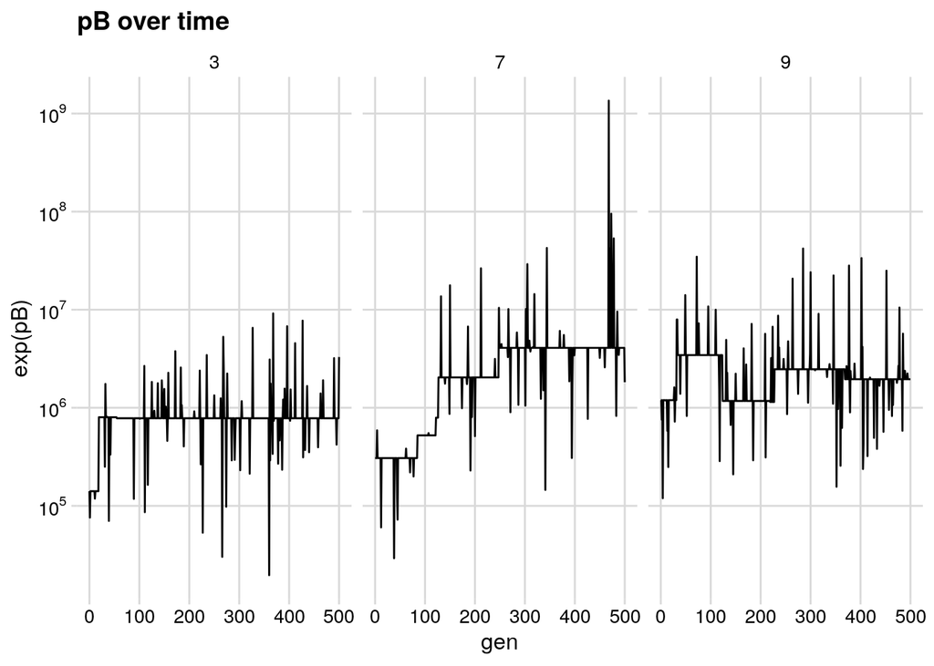

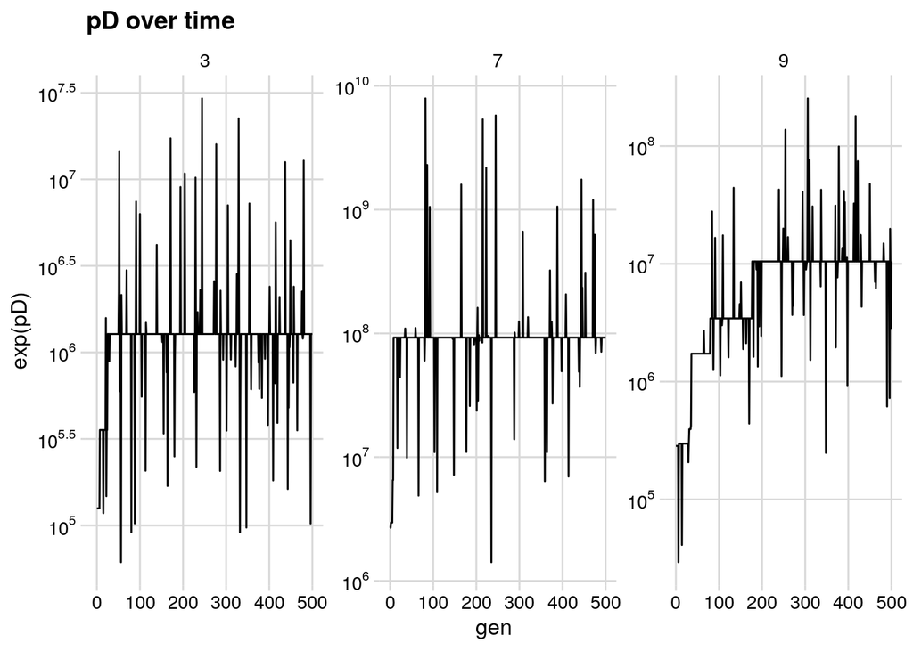

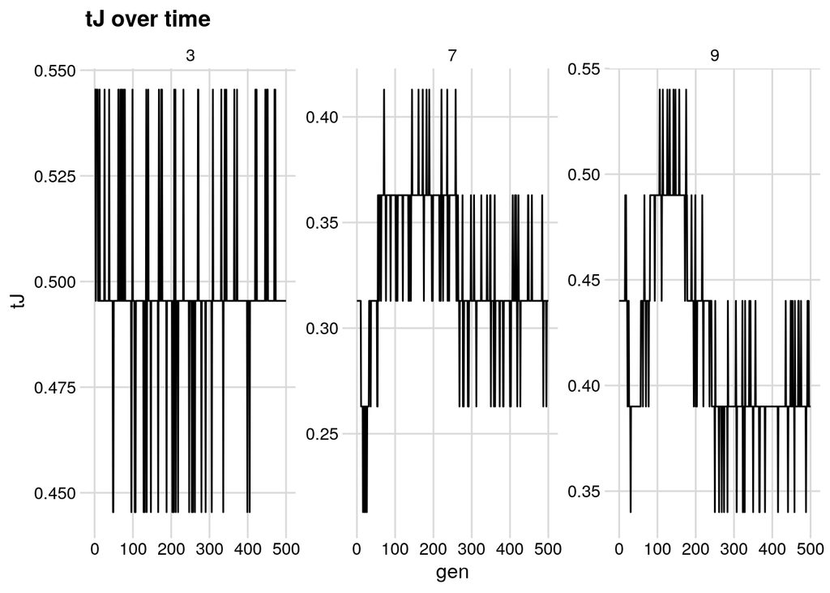

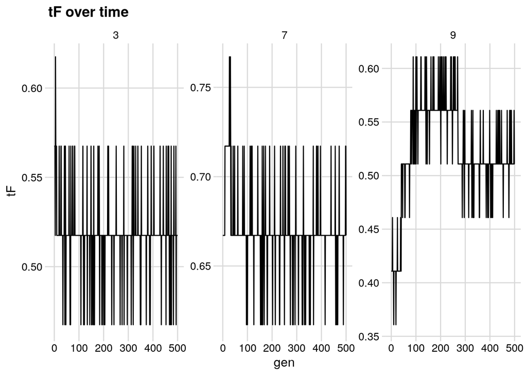

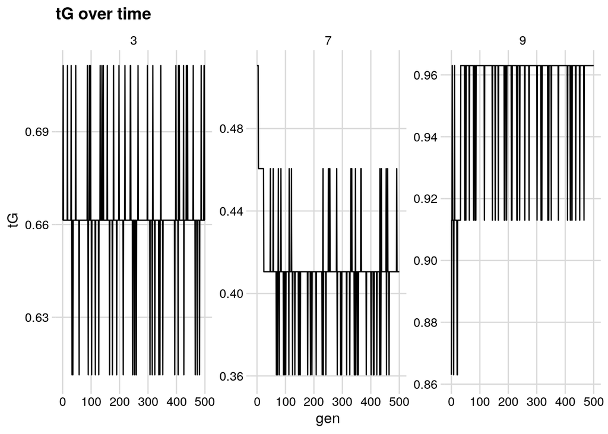

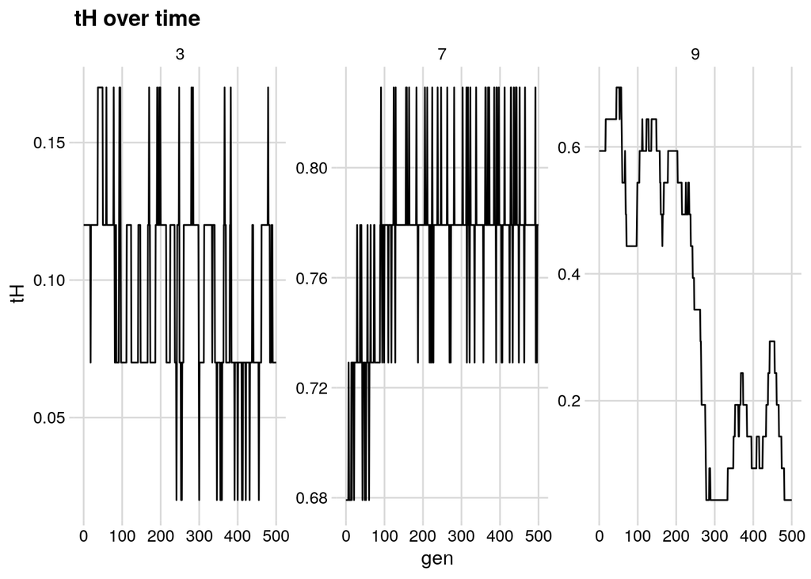

### **Next Steps**

Based on these results, I think I’m pretty much done with this phase of the project. Here is what I plan to do next to wrap things up:

1. **Optimize Terminator values with smaller step sizes**.
- Instead of using steps size of 0.05, I’m going to try 0.01. Hopefully this will help it converge better.
  - I’m also going to run for 1000 generations instead of 500. I know visually it seems like the error is minimized effectively after 400 generations…but hopefully this will provide more time/space for the terminator values to converge.
2. **Think about why promoter values do not follow experimentally-determined trends in value**
- Specifically, why is pD bigger than pB when the reported fold-change of pB is largest? Is there some regulatory mechanism that Pinetree is not capturing?